# HW2

Author

Brandy Recio

```r
install.packages("nycflights13", repos = "https://cloud.r-project.org")
library(nycflights13)
data(flights)
data(weather)
data(planes)
data(airports)
data(airlines)
library(dplyr)
library(ggplot2)
library(tidyverse)
```

## Question 1:

**Instructions:** Find the top 10 most popular destinations in the flights data. How many flight went into each one?

```r
top_destinations <- flights %>%
  group_by(dest) %>%
  summarise(total_flights = n()) %>%
  arrange(desc(total_flights)) %>%
  slice_head(n = 10)

print(top_destinations)
```

```
# A tibble: 10 × 2
   dest  total_flights
   <chr>         <int>
 1 ORD           17283
 2 ATL           17215
 3 LAX           16174
 4 BOS           15508
 5 MCO           14082
 6 CLT           14064
 7 SFO           13331
 8 FLL           12055
 9 MIA           11728
10 DCA            9705
```

**Q1 answer:** ORD (17283 flights), ATL (17215 flights), LAX (16174 flights), BOS (15508 flights), MCO (14082 flights), CLT (14064 flights), SFO (13331 flights), FLL (12055 flights), MIA (11728 flights) and DCA (9705) in 2013.

## Question 2:

**Instructions:** Create two new categorical variables in `flights` based on the departure time (`dep_time`), and arrival time (`arr_time`). These new variables should have four categories: “early morning” for 12am to 6am, “morning” for 6am to 12pm, “afternoon” for 12pm to 6pm, and “evening” for 6pm to 12am. Show barplots of both of these new variables. What percentage of flights were “red eye” flights?

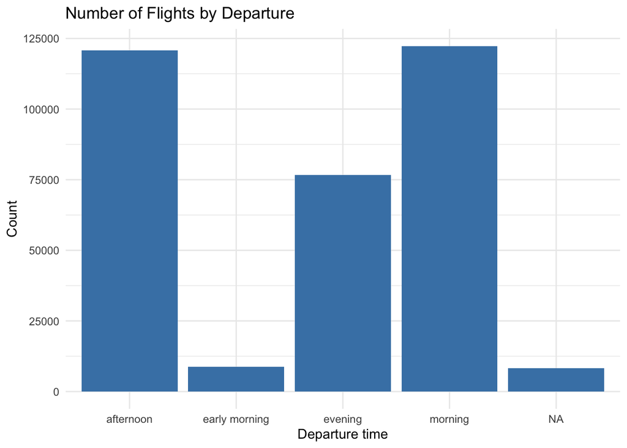

```r
#step 1: convert HHMM to hours (for instance, 523 -> 5.38 is 5h23m)
time_to_hour <- function(x) {
  ifelse(is.na(x), NA,
         floor(x / 100) + (x %% 100) / 60)}

#step 2: Add categorical variables for dep_time and arr_time
flights_timecat <- flights %>%
  mutate(dep_hour = time_to_hour(dep_time),
         arr_hour = time_to_hour(arr_time),
         dep_hour = case_when(
           dep_hour >= 0  & dep_hour < 6  ~ "early morning",
           dep_hour >= 6  & dep_hour < 12 ~ "morning",
           dep_hour >= 12 & dep_hour < 18 ~ "afternoon",
           dep_hour >= 18 & dep_hour < 24 ~ "evening",
           TRUE ~ NA_character_
         ),
         arr_hour = case_when(
           arr_hour >= 0  & arr_hour < 6  ~ "early morning",
           arr_hour >= 6  & arr_hour < 12 ~ "morning",
           arr_hour >= 12 & arr_hour < 18 ~ "afternoon",
           arr_hour >= 18 & arr_hour < 24 ~ "evening",
           TRUE ~ NA_character_
         ))
##step 3: show barplots for the variables
# Plot departure time
ggplot(flights_timecat, aes(x = dep_hour)) +
  geom_bar(fill = "steelblue") +
  labs(title = "Number of Flights by Departure",
       x = "Departure time",
       y = "Count") +
  theme_minimal()
```

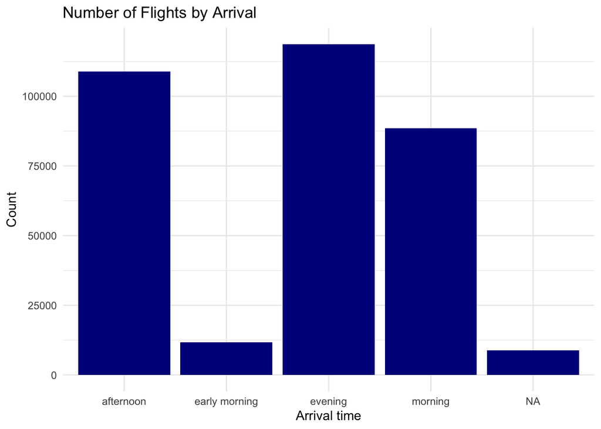

```r
# Plot arrival time
ggplot(flights_timecat, aes(x = arr_hour)) +
  geom_bar(fill = "darkblue") +
  labs(title = "Number of Flights by Arrival",
       x = "Arrival time",
       y = "Count") +
  theme_minimal()
```

```r
#step 4: Define red-eye flights
flights_timecat <- flights_timecat %>%
  mutate(red_eye = dep_hour %in% c("afternoon", "evening") &
                     arr_hour %in% c("early morning", "morning"))

#step 5: Calculate percentage of red-eye flights
red_eye_pct <- flights_timecat %>%
  summarise(percent_red_eye = mean(red_eye, na.rm = TRUE) * 100)
red_eye_pct
```

```
# A tibble: 1 × 1
  percent_red_eye
            <dbl>
1            3.15
```

**Q2 answer:** only 3.15% were red eye

## Question 3:

**Instructions:** Where there any planes that flew for multiple airlines? If so, how many were there and which airlines did they fly for?

This questions is asking if the same plane, in this database “tail number” was used by more than one airline.

```r
multi_airlines <- flights %>%
  filter(!is.na(tailnum)) %>%
  group_by(tailnum) %>%
  summarise(unique_airlines = n_distinct(carrier),
            airlines = paste(unique(carrier), collapse = ", "),
            .groups = "drop") %>%
  filter(unique_airlines > 1)
multi_airlines
```

```
# A tibble: 17 × 3
   tailnum unique_airlines airlines
   <chr>             <int> <chr>
 1 N146PQ                2 9E, EV
 2 N153PQ                2 9E, EV
 3 N176PQ                2 9E, EV
 4 N181PQ                2 9E, EV
 5 N197PQ                2 9E, EV
 6 N200PQ                2 9E, EV
 7 N228PQ                2 9E, EV
 8 N232PQ                2 9E, EV
 9 N933AT                2 FL, DL
10 N935AT                2 FL, DL
11 N977AT                2 FL, DL
12 N978AT                2 FL, DL
13 N979AT                2 FL, DL
14 N981AT                2 FL, DL
15 N989AT                2 FL, DL
16 N990AT                2 FL, DL
17 N994AT                2 FL, DL
```

## Question 4:

**What is the relationship and how should it appear in the diagram?**

**Q4 answer:** The missing relationship is that faa (unique ariport code, JFK,LGA,and EWR in this case) on airports represent “origin”. So weather origin should draw an arrow directly to faa on airports such that weather.origin –-> airport.faa

**The primary question:**

- *Which weather phenomena have the most impact on flight delays?*

## Question 5:

**Instructions:** In order to address our primary question, we want to prepare a tidy dataset (a single data frame). This will consist of information from the `flights` and `weather` data. The `year`, `month`, `day`, `hour`, and `origin` variables from `weather` provide *almost* enough information to give each observation a unique value. Create a new variable in the weather dataset by pasting together those 5 variables, then determine how many duplicated values there are and explain why.

```r
# Create a unique variable
weather_unique <- weather %>%
  mutate(key = paste(year, month, day, hour, origin, sep = "-"))
head(weather_unique$key)
```

```
[1] "2013-1-1-1-EWR" "2013-1-1-2-EWR" "2013-1-1-3-EWR" "2013-1-1-4-EWR"
[5] "2013-1-1-5-EWR" "2013-1-1-6-EWR"
```

```r
# Count duplicates
dup_count <- sum(duplicated(weather_unique$key))
dup_count
```

```
[1] 3
```

```r
#which are the dupplicated?
weather_unique %>%
  filter(key %in% key[duplicated(key)]) %>%
  arrange(key)
```

```
# A tibble: 6 × 16
  origin  year month   day  hour  temp  dewp humid wind_dir wind_speed wind_gust
  <chr>  <int> <int> <int> <int> <dbl> <dbl> <dbl>    <dbl>      <dbl>     <dbl>
1 EWR     2013    11     3     1  52.0  39.0  61.2      310       6.90        NA
2 EWR     2013    11     3     1  50    39.0  65.8      290       5.75        NA
3 JFK     2013    11     3     1  54.0  37.9  54.5      320       9.21        NA
4 JFK     2013    11     3     1  52.0  37.9  58.6      310       6.90        NA
5 LGA     2013    11     3     1  55.0  39.0  54.7      330       9.21        NA
6 LGA     2013    11     3     1  54.0  39.9  58.9      310       8.06        NA
# ℹ 5 more variables: precip <dbl>, pressure <dbl>, visib <dbl>,
#   time_hour <dttm>, key <chr>
```

**Instructions:** Now merge the `flights` data and the `weather` data so that each flight contains information about the weather at its **departure airport** at the time it was **scheduled** to take off. You’ll want to use the variables `time_hour` and `origin` in order to do this.

```r
names(weather)
```

```
 [1] "origin"     "year"       "month"      "day"        "hour"
 [6] "temp"       "dewp"       "humid"      "wind_dir"   "wind_speed"
[11] "wind_gust"  "precip"     "pressure"   "visib"      "time_hour"
```

```r
names(flights)
```

```
 [1] "year"           "month"          "day"            "dep_time"
 [5] "sched_dep_time" "dep_delay"      "arr_time"       "sched_arr_time"
 [9] "arr_delay"      "carrier"        "flight"         "tailnum"
[13] "origin"         "dest"           "air_time"       "distance"
[17] "hour"           "minute"         "time_hour"
```

```r
flights_weather <- flights %>%
  left_join(
    weather_unique %>%
      distinct(origin, time_hour, .keep_all = TRUE) %>%
      select(-year, -month, -day, -hour), #this is to avoid duplicates on year, month, day, and hour from both datasets (example year.y and year.x, only shows year)
    by = c("origin", "time_hour")
  )
```

## Question 6:

*Perform steps 2-5 of the EDA checklist*

**2) Visualize the data**

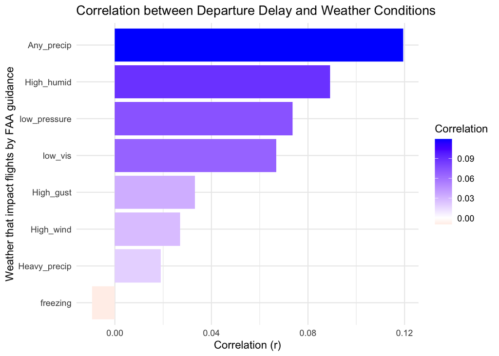

```r
library(dplyr)
library(tidyr)
library(ggplot2)

#1) Define weather conditions on the merged flights_weather data. The FAA and National Weather Service (NWS) define impact thresholds meaningful for flights. We need to set up the following conditions, otherwise higher values will lead to misinterpretations.
low_press_cut <- quantile(flights_weather$pressure, 0.10, na.rm = TRUE)

flights_weather_flags <- flights_weather %>%
  mutate(
    Any_precip   = precip > 0,
    Heavy_precip = precip >= 0.5,   # heavy precipitation
    low_vis      = visib <= 2,      # low visibility
    High_wind    = wind_speed >= 20,
    High_gust    = wind_gust >= 35,
    freezing     = temp <= 32,      # freezing temperature (°F)
    low_pressure = pressure <= low_press_cut,
    High_humid   = humid >= 90      # high humidity/moist air
  )

# 2) List of weather conditions
weather_flags <- c("Any_precip","Heavy_precip","low_vis","High_wind",
                   "High_gust","freezing","low_pressure","High_humid")

# 3) Compute correlations between dep_delay and each condition
cor_flags <- flights_weather_flags %>%
  select(dep_delay, all_of(weather_flags)) %>%
  filter(!is.na(dep_delay)) %>%
  summarise(across(all_of(weather_flags),
                   ~ cor(dep_delay, as.numeric(.), use = "complete.obs"))) %>%
  pivot_longer(everything(),
               names_to = "Weather_Flag",
               values_to = "Correlation")

# 4) Plot the flag correlations to see what wheather conditions contribute the most to delayed departures.
ggplot(cor_flags,
       aes(x = reorder(Weather_Flag, Correlation),
           y = Correlation,
           fill = Correlation)) +
  geom_col() +
  coord_flip() +
  scale_fill_gradient2(low = "red", mid = "white", high = "blue", midpoint = 0) +
  labs(
    title = "Correlation between Departure Delay and Weather Conditions",
    x = "Weather that impact flights by FAA guidance",
    y = "Correlation (r)"
  ) +
  theme_minimal()
```

  **3) look at numerical summaries of the data**

```r
library(dplyr)
library(purrr)
library(tidyr)

weather_conditions <- c("temp", "dewp", "humid", "wind_speed",
                  "wind_gust", "precip", "pressure", "visib")

stat_mode <- function(x) {
  x <- x[!is.na(x)]
  if (length(x) == 0) return(NA_real_)
  ux <- unique(x)
  ux[which.max(tabulate(match(x, ux)))]
}

# summary statistics
dep_delay_summary <- map_dfr(weather_conditions, function(v) {
  flights_weather %>%
    filter(!is.na(dep_delay), !is.na(.data[[v]])) %>%
    group_by(Weather_Variable = v, origin) %>%
    summarise(
      n                = n(),
      mean_dep_delay   = mean(dep_delay, na.rm = TRUE),
      median_dep_delay = median(dep_delay, na.rm = TRUE),
      mode_dep_delay   = stat_mode(dep_delay),
      sd_dep_delay     = sd(dep_delay, na.rm = TRUE),
      .groups = "drop"
    )
})

dep_delay_summary
```

```
# A tibble: 24 × 7
   Weather_Variable origin      n mean_dep_delay median_dep_delay mode_dep_delay
   <chr>            <chr>   <int>          <dbl>            <dbl>          <dbl>
 1 temp             EWR    116956           15.1               -1             -4
 2 temp             JFK    108875           12.1               -1             -3
 3 temp             LGA    101145           10.4               -3             -5
 4 dewp             EWR    116956           15.1               -1             -4
 5 dewp             JFK    108875           12.1               -1             -3
 6 dewp             LGA    101145           10.4               -3             -5
 7 humid            EWR    116956           15.1               -1             -4
 8 humid            JFK    108875           12.1               -1             -3
 9 humid            LGA    101145           10.4               -3             -5
10 wind_speed       EWR    116946           15.1               -1             -4
# ℹ 14 more rows
# ℹ 1 more variable: sd_dep_delay <dbl>
```

- **interpretation:** here I’m showing the central tendencies of weather conditions (mean,median, and mode) and spread (standard deviation) by origin (EWR,LGA,JFK). For example, EWR had the highest average departure delay due to wind gust, while LGA had the lowest average departure delay due to pressure in 2013.

  **4) Explore unusual values**

```r
# Missing values per column
na_counts <- sapply(flights_weather, function(x) sum(is.na(x)))
print(na_counts)
```

```
          year          month            day       dep_time sched_dep_time
             0              0              0           8255              0
     dep_delay       arr_time sched_arr_time      arr_delay        carrier
          8255           8713              0           9430              0
        flight        tailnum         origin           dest       air_time
             0           2512              0              0           9430
      distance           hour         minute      time_hour           temp
             0              0              0              0           1573
          dewp          humid       wind_dir     wind_speed      wind_gust
          1573           1573           9796           1634         256391
        precip       pressure          visib            key
          1556          38788           1556           1556
```

```r
# Calculate IQR-based outlier
q1 <- quantile(flights_weather$dep_delay, 0.25, na.rm = TRUE)
q3 <- quantile(flights_weather$dep_delay, 0.75, na.rm = TRUE)
iqr <- q3 - q1

lower_bound <- q1 - 1.5 * iqr
upper_bound <- q3 + 1.5 * iqr

cat("Lower bound:", lower_bound, "\nUpper bound:", upper_bound, "\n")
```

```
Lower bound: -29
Upper bound: 35
```

```r
# Extract potential outliers
unusual_delays <- flights_weather %>%
  filter(dep_delay < lower_bound | dep_delay > upper_bound) %>%
  select(origin, dep_delay, time_hour, everything())

# Show top extreme delays
unusual_delays %>%
  arrange(desc(dep_delay)) %>%
  head(10)
```

```
# A tibble: 10 × 29
   origin dep_delay time_hour            year month   day dep_time
   <chr>      <dbl> <dttm>              <int> <int> <int>    <int>
 1 JFK         1301 2013-01-09 09:00:00  2013     1     9      641
 2 JFK         1137 2013-06-15 19:00:00  2013     6    15     1432
 3 EWR         1126 2013-01-10 16:00:00  2013     1    10     1121
 4 JFK         1014 2013-09-20 18:00:00  2013     9    20     1139
 5 JFK         1005 2013-07-22 16:00:00  2013     7    22      845
 6 JFK          960 2013-04-10 19:00:00  2013     4    10     1100
 7 LGA          911 2013-03-17 08:00:00  2013     3    17     2321
 8 JFK          899 2013-06-27 19:00:00  2013     6    27      959
 9 LGA          898 2013-07-22 07:00:00  2013     7    22     2257
10 EWR          896 2013-12-05 17:00:00  2013    12     5      756
# ℹ 22 more variables: sched_dep_time <int>, arr_time <int>,
#   sched_arr_time <int>, arr_delay <dbl>, carrier <chr>, flight <int>,
#   tailnum <chr>, dest <chr>, air_time <dbl>, distance <dbl>, hour <dbl>,
#   minute <dbl>, temp <dbl>, dewp <dbl>, humid <dbl>, wind_dir <dbl>,
#   wind_speed <dbl>, wind_gust <dbl>, precip <dbl>, pressure <dbl>,
#   visib <dbl>, key <chr>
```

- **Interpretation:** first I checked whether there were any NAs, then used IQR to detect outliers (unusually high or low departure delays). after that, I filtered the rows that the departure delay is outside the IQR, and finally I showed the top 10 most delayed flights.

  **5) Explore relationships between variables**

```r
library(dplyr)
library(tidyr)
library(ggplot2)

# 1) Define weather conditions on flights_weather
low_press_cut <- quantile(flights_weather$pressure, 0.10, na.rm = TRUE)

weather_cond <- flights_weather %>%
  mutate(
    Any_precip   = precip > 0,
    Heavy_precip = precip >= 0.5,
    low_vis      = visib <= 2,
    High_wind    = wind_speed >= 20,
    High_gust    = wind_gust >= 35,
    freezing     = temp <= 32,
    low_pressure = pressure <= low_press_cut,
    High_humidity   = humid >= 90
  )

weather_flags <- c("Any_precip","Heavy_precip","low_vis","High_wind",
                   "High_gust","freezing","low_pressure","High_humidity")

# 2) Correlations between dep_delay and weather conditions by origin
cor_by_origin_flags <- weather_cond %>%
  filter(!is.na(dep_delay)) %>%
  group_by(origin) %>%
  summarise(
    across(
      all_of(weather_flags),
      ~ cor(dep_delay, as.numeric(.), use = "complete.obs"),
      .names = "{.col}_cor"
    ),
    .groups = "drop"
  ) %>%
  pivot_longer(
    cols = ends_with("_cor"),
    names_to = "Weather_Flag",
    values_to = "Correlation"
  ) %>%
  mutate(Weather_Flag = sub("_cor", "", Weather_Flag))

print(cor_by_origin_flags)
```

```
# A tibble: 24 × 3
   origin Weather_Flag  Correlation
   <chr>  <chr>               <dbl>
 1 EWR    Any_precip        0.113
 2 EWR    Heavy_precip      0.0182
 3 EWR    low_vis           0.0600
 4 EWR    High_wind         0.0241
 5 EWR    High_gust         0.0313
 6 EWR    freezing         -0.00331
 7 EWR    low_pressure      0.0798
 8 EWR    High_humidity     0.0882
 9 JFK    Any_precip        0.117
10 JFK    Heavy_precip      0.00232
# ℹ 14 more rows
```

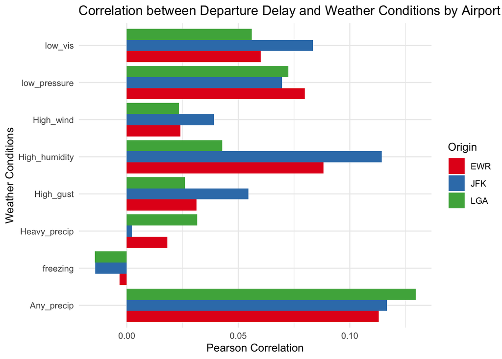

```r
# 3) plot
ggplot(cor_by_origin_flags, aes(x = Weather_Flag, y = Correlation, fill = origin)) +
  geom_col(position = "dodge") +
  coord_flip() +
  scale_fill_brewer(palette = "Set1") +
  labs(
    title = "Correlation between Departure Delay and Weather Conditions by Airport",
    x = "Weather Conditions",
    y = "Pearson Correlation",
    fill = "Origin"
  ) +
  theme_minimal()
```

**Interpretation:** here I’m showing the correlation weather conditions of most impact that I showed on step 2 by origin. You can see that the weather conditions of most impact varies among the airports. For example, while humidity and precipitations had the most impact on departure delay in JFK, precipitations had the greatest impact on flight delay in LGA and EWR.

## Question 7:

**Instructions:** Calculate the average departure delay for each **day** (Hint: think about which variables you need in order to do this!). Which day had the worst average length of delay for departures?

```r
daily_avg_delay <- flights %>%
  filter(!is.na(dep_delay)) %>%
  group_by(year, month, day) %>%
  summarise(
    avg_dep_delay = mean(dep_delay, na.rm = TRUE),
    n_flights = n(),
    .groups = "drop"
  ) %>%
  arrange(desc(avg_dep_delay))

worst_day <- slice_head(daily_avg_delay, n = 1)
worst_day
```

```
# A tibble: 1 × 5
   year month   day avg_dep_delay n_flights
  <int> <int> <int>         <dbl>     <int>
1  2013     3     8          83.5       799
```

- March 8th 2013 had the worst average departure delay across all airports.

**Instructions:** Now calculate the averages by **day** and **origin**. Which airport had the worst single day for delays and when was it?

```r
library(lubridate)

worst_avg_day <- flights %>%
  filter(!is.na(dep_delay)) %>%
  mutate(date = as_date(time_hour)) %>%
  group_by(origin, date) %>%
  summarise(
    avg_dep_delay = mean(dep_delay, na.rm = TRUE),
    n_flights = n(),
    .groups = "drop"
  ) %>%
  arrange(desc(avg_dep_delay)) %>%
  slice(1)

worst_avg_day
```

```
# A tibble: 1 × 4
  origin date       avg_dep_delay n_flights
  <chr>  <date>             <dbl>     <int>
1 LGA    2013-03-08          106.       229
```

- LGA airport had the worst single day (03/08/2013) for delays.

**Instructions:** Now calculate the averages by **hour** and **origin**. Which airport had the worst single hour for delays (and when was it)?

```r
hourly_delays <- flights %>%
  filter(!is.na(dep_delay)) %>%
  mutate(hour = lubridate::hour(time_hour)) %>%
  group_by(origin, year, month, day, hour) %>%
  summarise(
    avg_dep_delay = mean(dep_delay, na.rm = TRUE),
    n_flights = n(),
    .groups = "drop"
  )

worst_hour <- hourly_delays %>%
  slice_max(avg_dep_delay, n = 1, with_ties = FALSE)

worst_hour
```

```
# A tibble: 1 × 7
  origin  year month   day  hour avg_dep_delay n_flights
  <chr>  <int> <int> <int> <int>         <dbl>     <int>
1 LGA     2013     7    28    21          280.         3
```

- LGA had the worst single hr (9 PM) for delays in (07/28/2013)

## Question 8:

**Instructions:** Compute the average delay by destination, then add that information to the `airports` data frame. Make a map showing the spatial distribution of delays (you can make it however you like, but we recommend using either `ggplot` or `leaflet`). Use the color of the points to display the average delay for each airport.

```r
library(dplyr)
library(leaflet)

# 1) Average DEPARTURE delay by destination
avg_delay_dest <- flights %>%
  group_by(dest) %>%
  summarise(
    avg_dep_delay = mean(dep_delay, na.rm = TRUE),
    n = n(),
    .groups = "drop"
  ) %>%
  filter(!is.na(avg_dep_delay))

# 2) Join to airports (dest -> airports$faa)
airports_delay <- airports %>%
  select(faa, name, lat, lon) %>%
  inner_join(avg_delay_dest, by = c("faa" = "dest")) %>%
  filter(!is.na(lat), !is.na(lon))

pal <- colorNumeric("RdYlBu", domain = airports_delay$avg_dep_delay, reverse = TRUE)

leaflet(airports_delay) |>
  addTiles() |>
  addCircleMarkers(
    lng = ~lon, lat = ~lat,
    radius = ~pmax(3, pmin(12, sqrt(n)/4)),
    fillColor = ~pal(avg_dep_delay),
    fillOpacity = 0.85,
    stroke = FALSE,
    label = ~paste0(name, " (", faa, "): ",
                    round(avg_dep_delay, 1), " min; n=", n)
  ) |>
  addLegend("bottomright", pal = pal, values = ~avg_dep_delay,
            title = "Mean Departure Delay in Min", opacity =1)
```

[interactive chart not shown]

```r
avg_delay_dest <- flights %>%
  group_by(dest) %>%
  summarise(
    avg_arr_delay = mean(arr_delay, na.rm = TRUE),
    n = n(),
    .groups = "drop"
  ) %>%
  filter(!is.na(avg_arr_delay))

airports_delay <- airports %>%
  select(faa, name, lat, lon) %>%
  inner_join(avg_delay_dest, by = c("faa" = "dest")) %>%
  filter(!is.na(lat), !is.na(lon))

pal <- colorNumeric("RdYlBu", domain = airports_delay$avg_arr_delay, reverse = TRUE)

leaflet(airports_delay) |>
  addTiles() |>
  addCircleMarkers(
    lng = ~lon, lat = ~lat,
    radius = ~pmax(3, pmin(12, sqrt(n)/4)),
    fillColor = ~pal(avg_arr_delay),
    fillOpacity = 0.85,
    stroke = FALSE,
    label = ~paste0(name, " (", faa, "): ",
                    round(avg_arr_delay, 1), " min; n=", n)
  ) |>
  addLegend("bottomright", pal = pal, values = ~avg_arr_delay,
            title = "Mean Arrival Delay in Min", opacity = 1)
```

[interactive chart not shown]

## Question 9:

**Instructions:** Create as many plots and summary statistics as needed to answer the primary question above.

```r
library(dplyr)
library(tidyr)
library(ggplot2)

# 1) Define cutoff for "low pressure" (10th percentile)
low_press_cut <- quantile(flights_weather$pressure, 0.10, na.rm = TRUE)

# 2) Create weather condition flags
flights_weather_flags <- flights_weather %>%
  mutate(
    Any_precip   = !is.na(precip) & precip > 0,       # any precipitation
    Heavy_precip = !is.na(precip) & precip >= 0.5,    # heavy precipitation
    low_vis      = !is.na(visib) & visib <= 2,        # low visibility (<= 2 miles)
    High_wind    = !is.na(wind_speed) & wind_speed >= 20,  # high sustained wind
    High_gust    = !is.na(wind_gust) & wind_gust >= 35,    # high gusts
    freezing     = !is.na(temp) & temp <= 32,         # freezing temperatures (°F)
    low_pressure = !is.na(pressure) & pressure <= low_press_cut, # low barometric pressure
    High_humid   = !is.na(humid) & humid >= 90        # high humidity (>= 90%)
  )

# 3) List of all weather condition flags
weather_flags <- c(
  "Any_precip",
  "Heavy_precip",
  "low_vis",
  "High_wind",
  "High_gust",
  "freezing",
  "low_pressure",
  "High_humid"
)
# 4) Summarize mean dep_delay for each weather condition
weather_delay_summary <- flights_weather_flags %>%
  pivot_longer(
    cols = all_of(weather_flags),
    names_to = "Weather_Condition",
    values_to = "Condition_Flag"
  ) %>%
  filter(Condition_Flag == TRUE, !is.na(dep_delay)) %>%
  group_by(Weather_Condition) %>%
  summarise(
    n_flights   = n(),
    mean_delay  = mean(dep_delay, na.rm = TRUE),
    median_delay = median(dep_delay, na.rm = TRUE),
    sd_delay    = sd(dep_delay, na.rm = TRUE),
    .groups = "drop"
  ) %>%
  arrange(desc(mean_delay))
weather_delay_summary
```

```
# A tibble: 8 × 5
  Weather_Condition n_flights mean_delay median_delay sd_delay
  <chr>                 <int>      <dbl>        <dbl>    <dbl>
1 Heavy_precip            149       48.5           18     77.7
2 Any_precip            21086       30.9            5     59.2
3 low_vis                9730       28.0            2     59.6
4 High_humid            23245       25.6            1     54.6
5 low_pressure          28954       19.5            0     49.1
6 High_gust              4972       18.8            0     45.1
7 High_wind             19988       16.9            0     44.6
8 freezing              29530       11.4           -1     37.7
```

```r
# 5) top 5 weather conditions the had the greatest average impact (in time) in flight delays
top5_weather <- weather_delay_summary %>%
  slice_max(mean_delay, n = 5)
top5_weather
```

```
# A tibble: 5 × 5
  Weather_Condition n_flights mean_delay median_delay sd_delay
  <chr>                 <int>      <dbl>        <dbl>    <dbl>
1 Heavy_precip            149       48.5           18     77.7
2 Any_precip            21086       30.9            5     59.2
3 low_vis                9730       28.0            2     59.6
4 High_humid            23245       25.6            1     54.6
5 low_pressure          28954       19.5            0     49.1
```

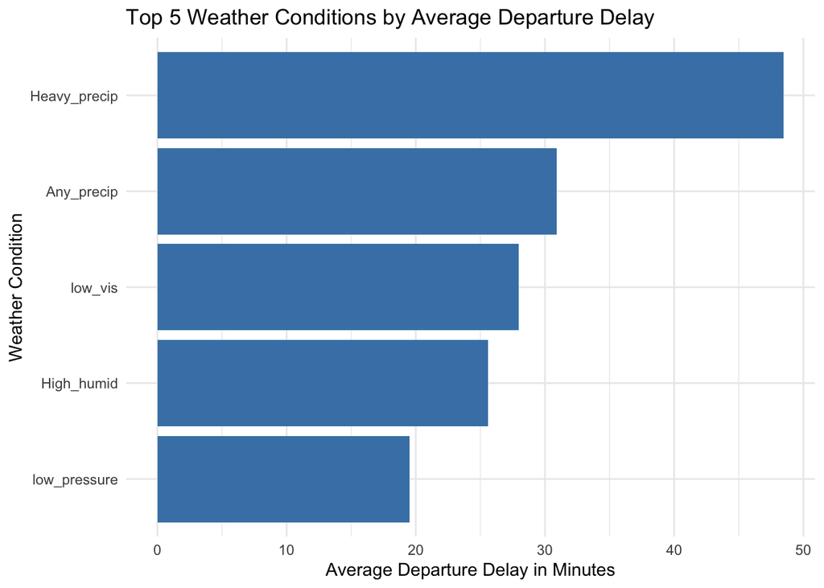

```r
# 6) plot
ggplot(top5_weather, aes(x = reorder(Weather_Condition, mean_delay), y = mean_delay)) +
  geom_col(fill = "steelblue") +
  coord_flip() +
  labs(
    title = "Top 5 Weather Conditions by Average Departure Delay",
    x = "Weather Condition",
    y = "Average Departure Delay in Minutes"
  ) +
  theme_minimal()
```

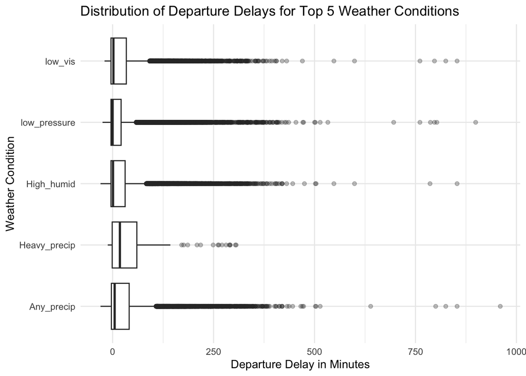

```r
# 7)boxplot
flights_weather_flags %>%
  pivot_longer(
    cols = all_of(weather_flags),
    names_to = "Weather_Condition",
    values_to = "Condition_Flag"
  ) %>%
  filter(Weather_Condition %in% top5_weather$Weather_Condition,
         Condition_Flag == TRUE,
         !is.na(dep_delay)) %>%
  ggplot(aes(x = Weather_Condition, y = dep_delay)) +
  geom_boxplot(outlier.alpha = 0.3) +
  coord_flip() +
  labs(
    title = "Distribution of Departure Delays for Top 5 Weather Conditions",
    x = "Weather Condition",
    y = "Departure Delay in Minutes"
  ) +
  theme_minimal()
```

**Conclusion:** Although any kind of precipitations occurred more frequently and contributed most broadly as shown in problem 6, heavy precipitations in particular caused the most delays in time when occurred. Thus, I showed not only the average impact in frequency but also in time (the longest delays) on flight delays.